# Mini-research project

Sophia Kholod

For my analysis I’ve decided to take the data on alcohol consumption(https://data.world/uncc-dsba/dsba-6100-fall-2016) and the average life expectancy(from the WHO - World Health Organization site (https://www.who.int/violence_injury_prevention/surveillance/databases/en/)).

So, our null hypothesis $H_0$ is that the alcohol consumption has linear relation with the average life duration (with some specific parameters). Respectively, $H_1$ - that there are no linear dependence.

```r
setwd("D:/R/labs") # !Important! Set this as a root directory of your project.Rmd file
set.seed(90)
all_life_duration <- read.csv(file="data/lifeexpectancy.csv", header=TRUE, sep=",")
alco <- read.csv(file="data/drinks.csv", header=TRUE, sep=",")
head(all_life_duration)
```

|  | GhoCode | GhoDisplay | PublishStateCode | PublishStateDisplay | YearCode | YearDisplay | RegionCode | RegionDisplay | WorldBankIncomeGroupGroupCode | WorldBankIncomeGroupDisplay | CountryCode | CountryDisplay | SexCode | SexDisplay | DisplayValue | Numeric |
| --- | --- | --- | --- | --- | --- | --- | --- | --- | --- | --- | --- | --- | --- | --- | --- | --- |
| 1 | WHOSIS_000001 | Life expectancy at birth (years) | PUBLISHED | Published | 2013 | 2013 | EMR | Eastern Mediterranean |  |  | AFG | Afghanistan | BTSX | Both sexes | 61 | 61.25205 |
| 2 | WHOSIS_000001 | Life expectancy at birth (years) | PUBLISHED | Published | 2013 | 2013 | EMR | Eastern Mediterranean |  |  | AFG | Afghanistan | FMLE | Female | 62 | 61.97733 |
| 3 | WHOSIS_000001 | Life expectancy at birth (years) | PUBLISHED | Published | 2013 | 2013 | EMR | Eastern Mediterranean |  |  | AFG | Afghanistan | MLE | Male | 61 | 60.51228 |
| 4 | WHOSIS_000001 | Life expectancy at birth (years) | PUBLISHED | Published | 2012 | 2012 | EMR | Eastern Mediterranean | WB_LI | Low_income | AFG | Afghanistan | BTSX | Both sexes | 60 | 60.00000 |
| 5 | WHOSIS_000001 | Life expectancy at birth (years) | PUBLISHED | Published | 2012 | 2012 | EMR | Eastern Mediterranean | WB_LI | Low_income | AFG | Afghanistan | FMLE | Female | 61 | 61.00000 |
| 6 | WHOSIS_000001 | Life expectancy at birth (years) | PUBLISHED | Published | 2012 | 2012 | EMR | Eastern Mediterranean | WB_LI | Low_income | AFG | Afghanistan | MLE | Male | 58 | 58.00000 |

At first, I calculated the total alcohol consumption in litres. To do that, I’ve googled the average amount of pure alcohol in all three types of drinks.

```r
total_alcohol = as.numeric(alco$beer_servings) * 0.045 + as.numeric(alco$spirit_servings) * 0.4 + as.numeric(alco$wine_servings) * 0.116
```

Selecting year 2013, both sexes, the average life expectancy at birth and the people of any income:

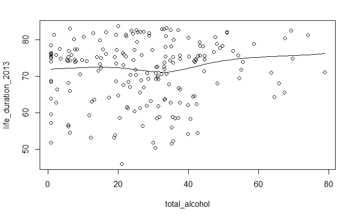

```r
life_duration_2013 = as.numeric(subset(all_life_duration, SexCode == "BTSX" & GhoCode == "WHOSIS_000001" & YearCode == 2013 & WorldBankIncomeGroupGroupCode == "")$Numeric)[sample(1:193)]
scatter.smooth(x=total_alcohol, y=life_duration_2013)
```

As we can see, the data hardly has any linear dependence, and also, our linear regression proves it:

```r
ln_reg = lm(life_duration_2013~total_alcohol)
summary(ln_reg)
```

```
Call:
lm(formula = life_duration_2013 ~ total_alcohol)

Residuals:
    Min      1Q  Median      3Q     Max
-24.925  -6.192   2.423   6.276  12.865

Coefficients:
              Estimate Std. Error t value Pr(>|t|)
(Intercept)   70.10114    1.16584  60.129   <2e-16 ***
total_alcohol  0.03856    0.03598   1.072    0.285
---
Signif. codes:  0 ‘***’ 0.001 ‘**’ 0.01 ‘*’ 0.05 ‘.’ 0.1 ‘ ’ 1

Residual standard error: 8.544 on 191 degrees of freedom
Multiple R-squared:  0.005976,  Adjusted R-squared:  0.0007719
F-statistic: 1.148 on 1 and 191 DF,  p-value: 0.2853
```

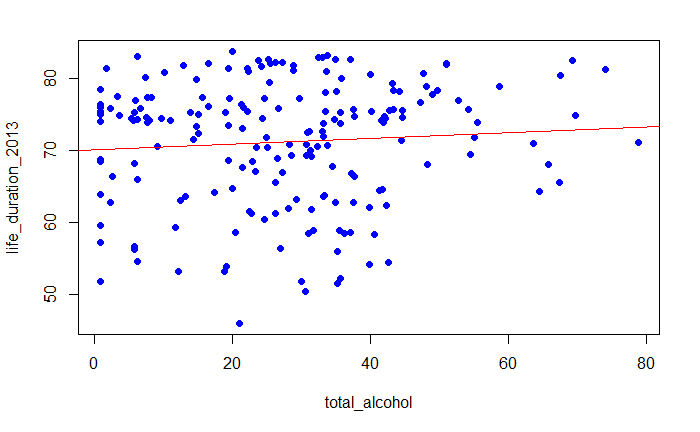

```r
plot(life_duration_2013 ~ total_alcohol, pch = 16, col = "blue")
abline(ln_reg, col = "red")
```

If we plot the residuals, it also tells us that our model is bad, so we reject $H_0$ that average life duration for both sexes with any income in year 2013 has any linear relation with alcohol consumption :

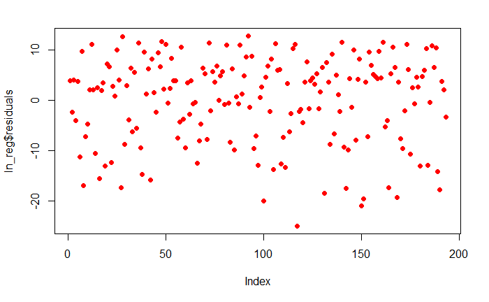

```r
plot(ln_reg$residuals, pch = 16, col = "red")
```

But we do not reject the general hyrothesis, so we’ll try to analyse people with similar income: Here we also use the data from a different year, because 2013 is not fully filled with the data we need. The best result I got is:

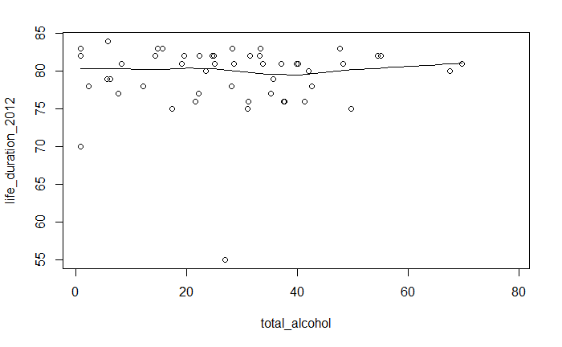

```r
life_duration_2012 = as.numeric(subset(all_life_duration, SexCode == "BTSX" & GhoCode == "WHOSIS_000001" & YearCode == 2012 & WorldBankIncomeGroupGroupCode == "WB_HI")$Numeric)[sample(1:193)]
scatter.smooth(x=total_alcohol, y=life_duration_2012)
```

But, surprisingly, our model turned out to be quite bad, $p$-value is still quite high, also, the determination coefficient is pretty low.

```r
ln_reg = lm(life_duration_2012~total_alcohol)
summary(ln_reg)
```

```
Call:
lm(formula = life_duration_2012 ~ total_alcohol)

Residuals:
    Min      1Q  Median      3Q     Max
-24.279  -1.756   1.556   2.706   4.987

Coefficients:
              Estimate Std. Error t value Pr(>|t|)
(Intercept)   78.93987    1.27252  62.034   <2e-16 ***
total_alcohol  0.01255    0.03899   0.322    0.749
---
Signif. codes:  0 ‘***’ 0.001 ‘**’ 0.01 ‘*’ 0.05 ‘.’ 0.1 ‘ ’ 1

Residual standard error: 4.568 on 49 degrees of freedom
  (142 observations deleted due to missingness)
Multiple R-squared:  0.002112,  Adjusted R-squared:  -0.01825
F-statistic: 0.1037 on 1 and 49 DF,  p-value: 0.7488
```

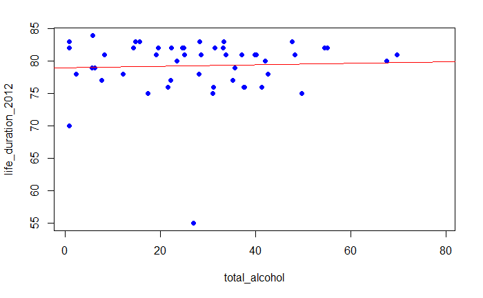

```r
plot(life_duration_2012 ~ total_alcohol, pch = 16, col = "blue") # Plot the results
abline(ln_reg, col = "red")
```

That happens because of the point, which has the life duration around 55 - the $\textbf{outlier}$. Deleting the outlier:

```r
my.min <- function(x) ifelse(!all(is.na(x)), min(x, na.rm=T), NA)
index <- which(life_duration_2012 %in% c(my.min(life_duration_2012)))
life_duration_2012 =  life_duration_2012[life_duration_2012!= my.min(life_duration_2012)]
total_alcohol = total_alcohol[total_alcohol != total_alcohol[index]][sample(1:length(life_duration_2012))]
```

```r
ln_reg12 = lm(life_duration_2012~total_alcohol)
summary(ln_reg12)
```

```
Call:
lm(formula = life_duration_2012 ~ total_alcohol)

Residuals:
     Min       1Q   Median       3Q      Max
-10.0964  -2.3361   0.7914   2.1103   4.3458

Coefficients:
              Estimate Std. Error t value Pr(>|t|)
(Intercept)   78.81545    0.77517 101.676   <2e-16 ***
total_alcohol  0.03393    0.02313   1.467    0.149
---
Signif. codes:  0 ‘***’ 0.001 ‘**’ 0.01 ‘*’ 0.05 ‘.’ 0.1 ‘ ’ 1

Residual standard error: 2.903 on 48 degrees of freedom
  (142 observations deleted due to missingness)
Multiple R-squared:  0.04291,   Adjusted R-squared:  0.02297
F-statistic: 2.152 on 1 and 48 DF,  p-value: 0.1489
```

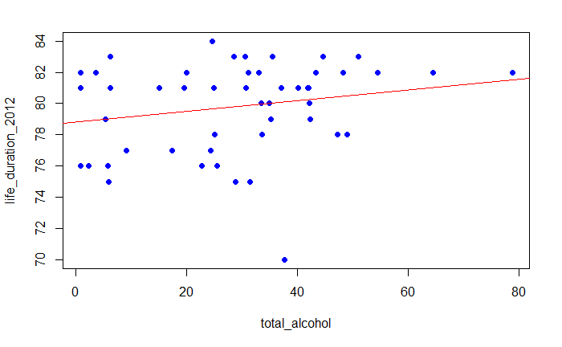

```r
plot(life_duration_2012~total_alcohol, pch = 16, col = "blue")
abline(ln_reg12, col = "red")
```

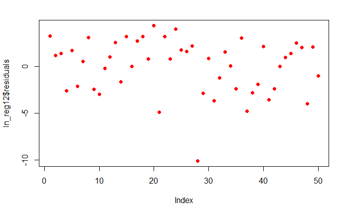

```r
plot(ln_reg12$residuals, pch = 16, col = "red")
```

## Summary

As can be seen, after cleaning the data we got significantly better $p$-value, but the determination coefficient is still very low, so we cannot say that alcohol consuption has any effect on the average life duration in a country.